# National GDP Growth and Changes of Stock Market Indices

Evidence from France, Germany, Great Britain and Japan

Daniel Limberg & Lukas Müller Hertie School of Governance

May 2016

[figure not shown]

A project by [Daniel Limberg](https://github.com/DanielLimberg) and [Lukas Müller](https://github.com/LukasMueller89).

If you would like to replicate our original paper, please fork our project from [the Project Page on Github](https://github.com/LukasMueller89/FinalPaper).If you have feedback, experience any issues using this site or simply find yourself offended by what we present, please let us [know](https://github.com/LukasMueller89/FinalPaper/issues).

# Introduction

Nowadays, equity prices have become the nexus between capitalism and our daily life on the globe. Especially the financial crisis and the following European sovereign debt crisis darken the beauty of this nexus, that was once proclaimed to be a good - if not the best - example of a functioning market mechanism.On this project page we present the results of our study in a nutshell: What is the key background for our research and what are our key assumptions and findings?  
We investigate an odd relation that is a part of the nexus: GDP growth and a subset of national equity prices; that is national stock indices. The intuitive assumption that one automatically has is fairly straight forward: The better the economy performs, the higher expectations of market participants, investments and trust in the future. In turn, we should - naturally - obtain an increase in the *level* of a national stock market indices given good economic performance within a country. In a way it is reasonable to argue, that national stock indices serve as a proxy of the economy. However, the more interesting question is beyond this intuitive assumption:  
We focus on four OECD countries: **France**, **Germany**, **Great Britain** and **Japan**. And we investigate whether GDP growth has an effect of the *changes* of the indices. If so, are there different levels of statistical significance for the effect of GDP growth across the different countries? That is, we do not compare the size of the effects (i.e. coefficients) since we investigate on different dependent variables. We take the four major national stock market indices of the countries as our dependent variable: The CAC40 (France), DAX (Germany), FTSE100 (Great Britain) and the NIKKEI (Japan). We control for a row of other, lagged explanatory determinants - not only from within the national economy (e.g. inflation rate) but also external, more global factors (e.g. oil price). We elaborate on the specific covariates below. For our analysis we focus on the time period between the beginning of 1999 (where ECB interest rates became relevant) and the end of 2015.

# What Others Found

Naturally, we are not the first ones to come up with the idea, that it might be interesting to have a closer look at the relationship of GDP growth and (national) stock market indices. So in the following, let us very briefly summarize what scolars found out about the topic.  
The field provides various studies which focus on the relationship between GDP growth (or macroeconomic determinants of GDP growth) and stock markets in general. For example, Claessens et al. “study how local stock market development and internationalization listing, trading, and capital raising in international exchanges are related to economic fundamentals” (Claessens, Klingebiel, and Schmukler 2006). Duca states that there is a clear co-movement between stock market prices and GDP in developed economies. Assuming causal effects he finds that “the level of economic activity in a country can potentially depend on the stock market amongst other variables” (Duca 2007). On the other hand, Ritter finds that cross-country correlation of real stock returns and per capita GDP growth over 1900-2002 is negative. This is mainly traced back to the fact that increases in capital and labor inputs (i.e. two main determinants of GDP growth) in new corporations (i.e. representing innovation) do not necessarily imply higher dividends (Ritter 2005).  
For 42 emerging markets Yartey examines the effect of institutional and macroeconomic determinants on stock market developments (Yartey 2008). Similar studies focus on these determinants for a wide range of countries. These include OECD countries like Belgium (Van Nieuwerburgh, Buelens, and Cuyvers 2006), France (Sraer and Thesmar 2007), Germany (Antonios 2010) or New Zealand from 1990 to 2003 (Diebold and Yilmaz 2008). And developing markets such as Malaysia (Rahman, Sidek, and Tafri 2009) or BRICS-countries like India (Singh 2010, Agrawalla and Tuteja (2007)) and South Africa (Hsing 2011) in general.

# What We Aimed to Find

Having outlined what the field has already done, let us now turn to our own Research Question and Hypothesis. They read as follows.

*Do changes in GDP growth lead to changes in the country’s national stock market index?*

- H<sub>0</sub>: There are statistically significant effects of GDP growth on the growth rates of a country’s stock market index.
- H<sub>1</sub>: There are no statistically significant effects of GDP growth on the growth rates of a country’s stock market index.

# Variables of Interest

In the following we introduce our variables of interest and briefly summarize how they fit our purpose. All variables were collected on (or aggregated to) a quarterly format.  
We derive all our data from the [ECB database](http://sdw.ecb.europa.eu), [Yahoo Finance](http://finance.yahoo.com/market-overview/?bypass=true) and the [OECD database](http://stats.oecd.org).

| **Variables** | Number | Origin of Data | Time Range |
| --- | --- | --- | --- |
| Dependent Variables | 4 | Yahoo Finance | Quarter 1 1999 - Q4 2015 |
| Covariates | 6 | ECB, OECD | Quarter 1 1999 - Q4 2015 |

## Dependent Variables

We use data from Yahoo Finance to derive four dependent variables. We are interested in equity prices in the form of national stock market indices for four OECD countries: France, Germany, Great Britain and Japan. The indices measure the combined stock values of companies and/or equities in a country which are top performing according to given benchmarks. We measure the dependent variables as the change of the average closing value from the previous quarter. In other words, we are not interested in the *level* but rather in the *variation* or *changes* of the indices over time.

[figure not shown]

| **Dependent Variables** | Official Title | Scope |
| --- | --- | --- |
| CAC40 (France) | Cotation Assisté en Continu 40 | 40 highest Market Caps |
| DAX (Germany) | Deutscher Aktienindex | 30 major Companies |
| FTSE100 (Great Britain) | Fin. Times Stock Exchange 100 Index | 100 Companies |
| NIKKEI (Japan) | NIKKEI 225 | 225 Equities |

## Covariates

In our paper we control for various covariates. We use a lag of one quarter and another lag of two quarters for all covariates. If not indicated differently, the default for the covariates is a lag of one quarter. For the control variables we differentiate between country-specific and general covariates that apply to all countries. Starting with country-specific covariates (i.e. variables that are unique to France, Germany, Great Britain and France), we use OECD data to derive the three following covariates. Among them is our key independent variable: GDP growth. We also use private consumption and the inflation rate (measured through the CPI) within the countries as additional control variables.

| **Country-specific Covariates** | Measured |
| --- | --- |
| GDP growth | % change to previous quarter |
| Consumer price index (CPI) | % change to previous quarter |
| Private consumption | % change of share of GDP to prev. quarter |

From the ECB database we use the deposit facility (i.e. interest rate for banks[^1] making overnight deposits with the Eurosystem). Quite noticeable is the fact that, since June 2014, the rate is negative. That is, quite counter-intuitive, banks are penalized when making deposits.  
Again using OECD data, we also take the quarterly GDP growth rate of the USA as a proxy for the general development of the world economy. The economy of the USA has a profound impact on other national business cycles, and national recessions in the US have sever repercussions across the globe. This was demonstrated again after 2007 when the US subprime mortgage crisis turned into a global recession. Moreover, the West Texas Intermediate (WTI) price changes are taken as an indicator of global economic health and a crucial determinant of economic growth.

| **Covariates** | Measured |
| --- | --- |
| ECB deposit facility | % change to previous quarter |
| GDP growth USA | % change to previous quarter |
| WTI | % change to previous quarter |

At the early stage of research for this paper other covariates were taken into account: the ECB’s interest rate on the main refinancing operations (MRO), the unemployment rate for the four countries of interest and the brent crude oil price. However, a first variance inflation factor (vif) test after prelimenary regressions suggested to ignore the mentioned variables.

# Some Overviews

Before going into some of our results let us describe what we can already see and understand without actually going into more sophisticated analysis. We shall start with our dependent variables, then have a closer look into our key independent variables and finally look how they correlate.

## Dependent Variables

Below we present a first interactive overview of the four dependent variables: The % change of the average closing value of the indices to the previous quarter. The graphs range from the first quarter in 1999 to the last quarter in 2015. Given the financial crisis, the CAC40, DAX, FTSE100 and NIKKEI share a remarkable but unsurprising downturn in the end of 2008 and in early 2009.

[interactive chart not shown]

## Independent Variables

Another interesting overview is given below. Here, we summarize the developments of our key independent variables over Q1 1999 until Q4 2015. Our country-specific, key independent variables measure GDP growth (i.e. change to previous quarter) for the country in question. Remarkable again is the major, well visible downturn during and in the aftermath of financial crisis in all four graphs.

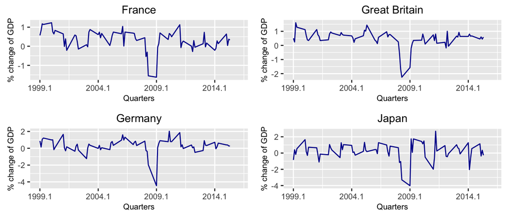

### Joint Distributions

[interactive chart not shown]

# What We Found

Finally, let us have a look into what we have found so far. Results indicate that the rate of GDP growth three month ago has somehwat of a predicitve vlaue when determining the performance of the national stock index. The numbers show that one percent GDP growht over a quater leads to roughly 8 percent increase in the average quaterly closign value of the CAC40. This relationship holds true for all other stock indices - a growing economy leads to better performing national stock indices. Whereas we can say that this relationship exists in the data for France, we cannot rely on the analysis with the same confidence for Germany, Great Britain, and especially Japan. For these countries the effect might as well not be different from zero.  
Looking at the quarterly change of the European Central Bank’s deposit facility the coefficient suggests that the more the interest rate increases the lower the performance of a national stock market index. In other terms, the negative effect suggests that when the deposit facility interest increases, banks’ revenues increase when storing their money overnight at the ECB. This implies that a high interest rate incentives the banks to keep money off markets. The negative effect suggests that increasing volumes of money held at banks does hurt the stock market: Less liquidity dampens investments. It seems straightforward that this effect is only weakly significant for Japan since Japanese banks are not directly affected by changes of the deposit facility. Moreover, the effect becomes statistical insignificance, when lagged by one period, can be explained by the outside lag of the political decision making process. Such decisions need at least six months to have an actual effect on the economy. The effects of a change in the central bank’s monetary policy on an individual may not become visible before a certain time has passed.  
The final model does explain a relatively larege portion of the variance in the dependent variable. When looking at the Adjusted R2 which is lowest for Germany with Adj.-R2=.36 and highest for France with Adj.-R2=.53 it should be noted, however, that a direct comparison is difficult to make. The four dependent variables are all differently composed, and thus, variables measuring the same concept may have a different effect across the four regression models.  
Finally, the results suggest to not reject the Null that there are statistically significant effects of GDP growth on the growth rates of a country’s stock index for France. For all other national stock indices we cannot accept the Null and have to conclude that there are no statistically significant effects of GDP growth on the growth rates of a country’s stock market index.

**Final model**

|  | *Dependent variable:* |  |  |  |
| --- | --- | --- | --- | --- |
|  | CAC40 | DAX | FTSE100 | NIKKEI |
|  | (1) | (2) | (3) | (4) |
| France GDP growth | 8.020** |  |  |  |
|  | (3.169) |  |  |  |
| France GDP growth (two q. lag) | 2.417 |  |  |  |
|  | (3.468) |  |  |  |
| France inflation | -9.222*** |  |  |  |
|  | (2.823) |  |  |  |
| France inflation (two q. lag) | -5.454* |  |  |  |
|  | (2.945) |  |  |  |
| France pr. consumption | -3.528 |  |  |  |
|  | (2.856) |  |  |  |
| France pr. consumption (two q. lag) | 1.320 |  |  |  |
|  | (2.972) |  |  |  |
| Germany GDP growth |  | 3.717* |  |  |
|  |  | (2.011) |  |  |
| Germany GDP growth (two q. lag) |  | 0.447 |  |  |
|  |  | (1.815) |  |  |
| Germany inflation |  | -9.295* |  |  |
|  |  | (4.771) |  |  |
| Germany inflation (two q. lag) |  | -1.893 |  |  |
|  |  | (4.869) |  |  |
| Germany pr. consumption |  | -2.408 |  |  |
|  |  | (2.412) |  |  |
| Germany pr. consumption (two q. lag) |  | -0.632 |  |  |
|  |  | (2.441) |  |  |
| Great Britain GDP growth |  |  | 1.823 |  |
|  |  |  | (1.754) |  |
| Great Britain GDP growth (two quarter lag) |  |  | 2.609 |  |
|  |  |  | (2.013) |  |

[output cut: 72 more lines]

# Limitations

# Future Research

Future Research could further invest into interactions: Is the true effect of GDP growth on changes of national stock market indices dependent on a second covariate? Also interesting should be approaches that aim for a higher external validity than we did: Studies could include national indices of other OECD countries or re-focus solely on BRICS or developing countries.Another pathway for future research could be to stay closer to the format of the original raw data: While we collapsed and aggregated data to quarterly format, analysis with monthly, weekly or even daily data should yield some interesting results. Especially, since we found that the effects of changes in GDP growth on the changes of national stock market indices are of rather immediate than long-term nature.

# Conclusion

# Acknowledgments

We would like to take the opportunity to acknowledge not only the inventors of R (R Core Team 2014) but also the surrounding community that supplies fantastic add-on packages. Without their appreciated work, this paper could not have been written (Bache and Wickham 2014, Hlavac (2015), Wickham (2009), Maindonald and Braun (2014), Wickham (2011), Wickham (2014), Zeileis and Grothendieck (2005), Hope (2013), Gandrud (2016b), Gandrud (2016a), Arel-Bundock (2014), Arel-Bundock (2013)). Finally, we also would like to acknowledge the providers of our raw-data: Yahoo Finance, the OECD database and the ECB website.

# Bibliography

Agrawalla, Raman K, and SK Tuteja. 2007. “Causality Between Stock Market Development and Economic Growth: A Case Study of India.” *Journal of Management Research* 7 (3). South Asia Publications: 158.

Antonios, Adamopoulos. 2010. “Stock Market and Economic Growth: An Empirical Analysis for Germany.” *Business and Economics Journal* 2010. HATASO Enterprises, LLC: 1–12.

Arel-Bundock, Vincent. 2013. *WDI: World Development Indicators (World Bank)*. https://cran.r-project.org/web/packages/WDI/index.html.

———. 2014. *Countrycode: Convert Country Names and Country Codes*. https://cran.r-project.org/web/packages/countrycode/index.html.

Bache, Stefan Milton, and Hadley Wickham. 2014. *Magrittr: A Forward-Pipe Operator for R*. https://CRAN.R-project.org/package=magrittr.

Claessens, Stijn, Daniela Klingebiel, and Sergio L Schmukler. 2006. “Stock Market Development and Internationalization: Do Economic Fundamentals Spur Both Similarly?” *Journal of Empirical Finance* 13 (3). Elsevier: 316–50.

Diebold, Francis X, and Kamil Yilmaz. 2008. “Macroeconomic Volatility and Stock Market Volatility, Worldwide.” National Bureau of Economic Research.

Duca, Gevit. 2007. “The Relationship Between the Stock Market and the Economy: Experience from International Financial Markets.” *Bank of Valletta Review* 36 (3): 1–12.

Gandrud, Christopher. 2016a. *DataCombine: Tools for Easily Combining and Cleaning Data Sets*. Berlin, Germany: Hertie School of Governance. https://cran.r-project.org/web/packages/DataCombine/index.html.

———. 2016b. *Repmis: Miscellaneous Tools for Reproducible Research*. https://CRAN.R-project.org/package=repmis.

Hlavac, Marek. 2015. *Stargazer: Well-Formatted Regression and Summary Statistics Tables*. Cambridge, USA: Harvard University. http://CRAN.R-project.org/package=stargazer.

Hope, Ryan M. 2013. *Rmisc: Rmisc: Ryan Miscellaneous*. http://CRAN.R-project.org/package=Rmisc.

Hsing, Yu. 2011. “The Stock Market and Macroeconomic Variables in a BRICS Country and Policy Implications.” *International Journal of Economics and Financial Issues* 1 (1). Econjournals: 12.

Maindonald, John H., and W. John Braun. 2014. *DAAG: Data Analysis And Graphics Data and Functions*. http://CRAN.R-project.org/package=DAAG.

R Core Team. 2014. *R: A Language and Environment for Statistical Computing*. Vienna, Austria: R Foundation for Statistical Computing. http://www.R-project.org/.

Rahman, Aisyah Abdul, Noor Zahirah Mohd Sidek, and Fauziah Hanim Tafri. 2009. “Macroeconomic Determinants of Malaysian Stock Market.” *African Journal of Business Management* 3 (3). Academic Journals: 95.

Ritter, Jay R. 2005. “Economic Growth and Equity Returns.” 5. *Pacific-Basin Finance Journal*. Vol. 13. Elsevier.

Singh, Dharmendra. 2010. “Causal Relationship Between Macro-Economic Variables and Stock Market: A Case Study for India.” *Pakistan Journal of Social Sciences* 30 (2): 263–74.

Sraer, David, and David Thesmar. 2007. “Performance and Behavior of Family Firms: Evidence from the French Stock Market.” *Journal of the European Economic Association* 5 (4). Wiley Online Library: 709–51.

Van Nieuwerburgh, Stijn, Frans Buelens, and Ludo Cuyvers. 2006. “Stock Market Development and Economic Growth in Belgium.” *Explorations in Economic History* 43 (1). Elsevier: 13–38.

Wickham, Hadley. 2009. *Ggplot2: Elegant Graphics for Data Analysis*. Springer-Verlag New York. http://ggplot2.org.

———. 2011. “The Split-Apply-Combine Strategy for Data Analysis.” *Journal of Statistical Software* 40 (1): 1–29. http://www.jstatsoft.org/v40/i01/.

———. 2014. *Reshape: Flexibly Reshape Data.* https://CRAN.R-project.org/package=reshape.

Yartey, Charles Amo. 2008. “The Determinants of Stock Market Development in Emerging Economies: Is South Africa Different?” *IMF Working Papers*, 1–31.

Zeileis, Achim, and Gabor Grothendieck. 2005. “Zoo: S3 Infrastructure for Regular and Irregular Time Series.” *Journal of Statistical Software* 14 (6): 1–27. doi:10.18637/jss.v014.i06.